# Individualized Student Instruction Principal Component and Regression Analyses

Alexis Swanz

2023-05-01

## Principal Component Analysis

```r
library(tidyverse) #call in packages
library(psych)
library(dplyr)
library(relaimpo)
library(caret)
```

## Data Wrangling

The Project KIDS dataset (available on LDbase) is a comprehensive set of data from 9 RCTs. Thus, I will start by calling in the dataset and filtering out the unwanted data, only keeping data from project 1 (Al Otaibia et al., 2011). Next, I will select variables of interest, remove NAs, and rename variables for clarity.

```r
PK_full <- read_csv("PK_FullData.csv") #importing the CSV file of complete Project KIDS data
PK_project1 <- PK_full %>% #calling the dataframe
  filter(project == "1") #filtering to only keep data from project one
```

### cleaning

```r
PKp1_WJ_scores <- PK_project1 %>% #calling the dataframe
  filter(!is.na(PK_ID),!is.na(sID),!is.na(Race), !is.na(Gender), !is.na(FARL), !is.na(LEP), !is.na(Ethnicity), !is.na(treatment), !is.na(PS_5), !is.na(PS_9), !is.na(CTOPP_Blend_Total_w1), !is.na(CTOPP_EL_Total_w1), !is.na(WJ_AKA_Total_w1), !is.na(WJ_LW_Total_w1), !is.na(WJ_PV_Total_w1), !is.na(WJ_PC_Total_w1), !is.na(WJ_WA_Total_w1), !is.na(KBIT_Total_Matrices), !is.na(KBIT_Total_Riddles), !is.na(KBIT_Total_Verbal)) %>% #filtering out NAs from all variables
  dplyr::select(PK_ID, sID, Race, Ethnicity, Gender, FARL, LEP, treatment, WJ_AKA_Total_w1, PS_5, PS_9, CTOPP_Blend_Total_w1, CTOPP_EL_Total_w1,  WJ_LW_Total_w1, WJ_PV_Total_w1, WJ_PC_Total_w1, WJ_WA_Total_w1,KBIT_Total_Matrices, KBIT_Total_Riddles,KBIT_Total_Verbal) #selecting variables I want

PKp1_WJ_scores #print
```

```
## # A tibble: 458 × 20
##    PK_ID   sID  Race Ethnicity Gender  FARL   LEP treatment WJ_AKA…¹  PS_5  PS_9
##    <dbl> <dbl> <dbl>     <dbl>  <dbl> <dbl> <dbl>     <dbl>    <dbl> <dbl> <dbl>
##  1 10000     1     3         0      0     1     0         1       14     3     4
##  2 10001     1     3         0      1     1     0         1       13     2     3
##  3 10004     1     3         0      0     1     0         1       11     3     3
##  4 10009     1     3         0      0     1     0         1        8     2     2
##  5 10010     1     3         0      1     1     0         1       11     3     1
##  6 10012     1     3         0      0     1     0         1       10     3     3
##  7 10013     1     3         0      0     1     0         1       11     2     2
##  8 10014     1     3         0      1     1     0         1       10     3     1
##  9 10015     1     3         0      1     1     0         1        9     3     2
## 10 10018     1     3         0      1     0     0         1       12     3     4
## # … with 448 more rows, 9 more variables: CTOPP_Blend_Total_w1 <dbl>,
## #   CTOPP_EL_Total_w1 <dbl>, WJ_LW_Total_w1 <dbl>, WJ_PV_Total_w1 <dbl>,
## #   WJ_PC_Total_w1 <dbl>, WJ_WA_Total_w1 <dbl>, KBIT_Total_Matrices <dbl>,
## #   KBIT_Total_Riddles <dbl>, KBIT_Total_Verbal <dbl>, and abbreviated variable
## #   name ¹WJ_AKA_Total_w1
```

### renaming and recoding

```r
PKp1_labeled <- PKp1_WJ_scores %>% #call df
  dplyr::rename(parent_time_read = PS_5, parent_edu = PS_9, letter_ID = WJ_LW_Total_w1, passage_comp = WJ_PC_Total_w1, picture_vocab = WJ_PV_Total_w1, word_attack = WJ_WA_Total_w1, KBIT_matrices = KBIT_Total_Matrices, KBIT_riddles = KBIT_Total_Riddles, KBIT_verbal = KBIT_Total_Verbal, limited_english_proficiency = LEP, free_reduced_lunch = FARL, CTOPP_Blend = CTOPP_Blend_Total_w1 , CTOPP_EL = CTOPP_EL_Total_w1, academic_knowledge = WJ_AKA_Total_w1) %>%   #renaming for clarity
  mutate(Gender = recode(Gender, "0" = "female", "1" = "male"), Ethnicity = recode(Ethnicity, "0" = "Not hispanic", "1" = "Hispanic"), Race = recode(Race, "1" = "American Indian/Alaskan Native", "2" = "Asian", "3" = "AA/Black", "4" = "Hawaiian/Pacific Islander", "5" = "Caucasian/White", "6" = "Multiracial", "7" = "Other"), free_reduced_lunch = recode(free_reduced_lunch, "0" = "Not FARL", "1" = "FARL"), limited_english_proficiency = recode(limited_english_proficiency, "0" = "Not LEP", "1" = "LEP"),  treatment = recode(treatment, "0" = "control", "1" = "treatment"))

PKp1_labeled #print
```

```
## # A tibble: 458 × 20
##    PK_ID   sID Race     Ethnicity Gender free_…¹ limit…² treat…³ acade…⁴ paren…⁵
##    <dbl> <dbl> <chr>    <chr>     <chr>  <chr>   <chr>   <chr>     <dbl>   <dbl>
##  1 10000     1 AA/Black Not hisp… female FARL    Not LEP treatm…      14       3
##  2 10001     1 AA/Black Not hisp… male   FARL    Not LEP treatm…      13       2
##  3 10004     1 AA/Black Not hisp… female FARL    Not LEP treatm…      11       3
##  4 10009     1 AA/Black Not hisp… female FARL    Not LEP treatm…       8       2
##  5 10010     1 AA/Black Not hisp… male   FARL    Not LEP treatm…      11       3
##  6 10012     1 AA/Black Not hisp… female FARL    Not LEP treatm…      10       3
##  7 10013     1 AA/Black Not hisp… female FARL    Not LEP treatm…      11       2
##  8 10014     1 AA/Black Not hisp… male   FARL    Not LEP treatm…      10       3
##  9 10015     1 AA/Black Not hisp… male   FARL    Not LEP treatm…       9       3
## 10 10018     1 AA/Black Not hisp… male   Not FA… Not LEP treatm…      12       3
## # … with 448 more rows, 10 more variables: parent_edu <dbl>, CTOPP_Blend <dbl>,
## #   CTOPP_EL <dbl>, letter_ID <dbl>, picture_vocab <dbl>, passage_comp <dbl>,
## #   word_attack <dbl>, KBIT_matrices <dbl>, KBIT_riddles <dbl>,
## #   KBIT_verbal <dbl>, and abbreviated variable names ¹free_reduced_lunch,
## #   ²limited_english_proficiency, ³treatment, ⁴academic_knowledge,
## #   ⁵parent_time_read
```

### Demographic Information

```r
table(PKp1_labeled$Gender) #creating table of count for Gender
```

```
##
## female   male
##    217    241
```

```r
table(PKp1_labeled$Race) #creating table of count for Race
```

```
##
##                  AA/Black                     Asian           Caucasian/White
##                       270                         7                       170
## Hawaiian/Pacific Islander               Multiracial                     Other
##                         2                         6                         3
```

```r
table(PKp1_labeled$treatment) #creating table of count for treatment
```

```
##
##   control treatment
##       190       268
```

```r
table(PKp1_labeled$free_reduced_lunch) #creating table of count for FARL
```

```
##
##     FARL Not FARL
##      254      204
```

```r
table(PKp1_labeled$limited_english_proficiency) #creating table of count for LEP
```

```
##
##     LEP Not LEP
##      12     446
```

## PCA

### STEP 1: Correlations for Strong Multicollinearity

First, I need to run a correlation matrix to check for multicollinearity. If there are instances of multicollinearity I will remove those variables one by one starting with the variable possessing the highest correlation coefficient.

```r
str(PKp1_labeled) #check structure
```

```
## tibble [458 × 20] (S3: tbl_df/tbl/data.frame)
##  $ PK_ID                      : num [1:458] 10000 10001 10004 10009 10010 ...
##  $ sID                        : num [1:458] 1 1 1 1 1 1 1 1 1 1 ...
##  $ Race                       : chr [1:458] "AA/Black" "AA/Black" "AA/Black" "AA/Black" ...
##  $ Ethnicity                  : chr [1:458] "Not hispanic" "Not hispanic" "Not hispanic" "Not hispanic" ...
##  $ Gender                     : chr [1:458] "female" "male" "female" "female" ...
##  $ free_reduced_lunch         : chr [1:458] "FARL" "FARL" "FARL" "FARL" ...
##  $ limited_english_proficiency: chr [1:458] "Not LEP" "Not LEP" "Not LEP" "Not LEP" ...
##  $ treatment                  : chr [1:458] "treatment" "treatment" "treatment" "treatment" ...
##  $ academic_knowledge         : num [1:458] 14 13 11 8 11 10 11 10 9 12 ...
##  $ parent_time_read           : num [1:458] 3 2 3 2 3 3 2 3 3 3 ...
##  $ parent_edu                 : num [1:458] 4 3 3 2 1 3 2 1 2 4 ...
##  $ CTOPP_Blend                : num [1:458] 6 11 6 8 4 8 4 6 3 6 ...
##  $ CTOPP_EL                   : num [1:458] 8 3 4 3 0 1 0 2 2 3 ...
##  $ letter_ID                  : num [1:458] 12 9 14 15 8 10 12 13 14 16 ...
##  $ picture_vocab              : num [1:458] 20 18 16 12 17 16 17 16 15 15 ...
##  $ passage_comp               : num [1:458] 8 7 0 3 5 6 3 7 4 7 ...
##  $ word_attack                : num [1:458] 3 2 3 2 2 3 3 2 3 3 ...
##  $ KBIT_matrices              : num [1:458] 26 17 17 13 12 11 12 17 14 14 ...
##  $ KBIT_riddles               : num [1:458] 16 12 10 10 12 9 10 13 11 12 ...
##  $ KBIT_verbal                : num [1:458] 22 17 9 8 9 7 5 9 9 14 ...
```

```r
PKp1_corr <- PKp1_labeled[,10:20]#create dataframe for correlation

corr_PKp1 <- cor(PKp1_corr) #run correlation

corr_PKp1 #print results
```

```
##                  parent_time_read parent_edu CTOPP_Blend  CTOPP_EL letter_ID
## parent_time_read       1.00000000  0.1561627   0.1272931 0.1011845 0.1773731
## parent_edu             0.15616274  1.0000000   0.3145071 0.2913208 0.2820855
## CTOPP_Blend            0.12729306  0.3145071   1.0000000 0.6712642 0.5725524
## CTOPP_EL               0.10118448  0.2913208   0.6712642 1.0000000 0.5569337
## letter_ID              0.17737313  0.2820855   0.5725524 0.5569337 1.0000000
## picture_vocab          0.14987975  0.2479460   0.4166277 0.4677310 0.4090547
## passage_comp           0.12441627  0.1461444   0.3869278 0.4155263 0.5317397
## word_attack            0.11235337  0.2138831   0.6034815 0.5467715 0.7462636
## KBIT_matrices          0.03288435  0.1675817   0.3395721 0.3500883 0.3333225
## KBIT_riddles           0.13655731  0.2669959   0.4701817 0.5049733 0.3923529
## KBIT_verbal            0.09575800  0.3493233   0.4288124 0.4684594 0.3083369
##                  picture_vocab passage_comp word_attack KBIT_matrices
## parent_time_read     0.1498798    0.1244163   0.1123534    0.03288435
## parent_edu           0.2479460    0.1461444   0.2138831    0.16758172
## CTOPP_Blend          0.4166277    0.3869278   0.6034815    0.33957212
## CTOPP_EL             0.4677310    0.4155263   0.5467715    0.35008830
## letter_ID            0.4090547    0.5317397   0.7462636    0.33332246
## picture_vocab        1.0000000    0.1809282   0.3258425    0.31109707
## passage_comp         0.1809282    1.0000000   0.4966382    0.21710802
## word_attack          0.3258425    0.4966382   1.0000000    0.28514237
## KBIT_matrices        0.3110971    0.2171080   0.2851424    1.00000000
## KBIT_riddles         0.6182148    0.2506831   0.3454523    0.44933626
## KBIT_verbal          0.5699978    0.2051811   0.3197380    0.38795680
##                  KBIT_riddles KBIT_verbal
## parent_time_read    0.1365573   0.0957580
## parent_edu          0.2669959   0.3493233
## CTOPP_Blend         0.4701817   0.4288124
## CTOPP_EL            0.5049733   0.4684594
## letter_ID           0.3923529   0.3083369
## picture_vocab       0.6182148   0.5699978
## passage_comp        0.2506831   0.2051811
## word_attack         0.3454523   0.3197380
## KBIT_matrices       0.4493363   0.3879568
## KBIT_riddles        1.0000000   0.6699748
## KBIT_verbal         0.6699748   1.0000000
```

There are no instances of multicollinearity among variables.

### STEP 2: Scale all the variables

Next, I will be scaling all of the variables included in the model. Variables with larger variances will consequently explain most of the variance. However, if variables in the data set are not on the same scale, variables with a larger scale will likely have the largest variance. Thus, it is crucial to scale the variables included in the model so the explained variance is not affected.

```r
library(psych)

str(PKp1_corr)#check structure
```

```
## tibble [458 × 11] (S3: tbl_df/tbl/data.frame)
##  $ parent_time_read: num [1:458] 3 2 3 2 3 3 2 3 3 3 ...
##  $ parent_edu      : num [1:458] 4 3 3 2 1 3 2 1 2 4 ...
##  $ CTOPP_Blend     : num [1:458] 6 11 6 8 4 8 4 6 3 6 ...
##  $ CTOPP_EL        : num [1:458] 8 3 4 3 0 1 0 2 2 3 ...
##  $ letter_ID       : num [1:458] 12 9 14 15 8 10 12 13 14 16 ...
##  $ picture_vocab   : num [1:458] 20 18 16 12 17 16 17 16 15 15 ...
##  $ passage_comp    : num [1:458] 8 7 0 3 5 6 3 7 4 7 ...
##  $ word_attack     : num [1:458] 3 2 3 2 2 3 3 2 3 3 ...
##  $ KBIT_matrices   : num [1:458] 26 17 17 13 12 11 12 17 14 14 ...
##  $ KBIT_riddles    : num [1:458] 16 12 10 10 12 9 10 13 11 12 ...
##  $ KBIT_verbal     : num [1:458] 22 17 9 8 9 7 5 9 9 14 ...
```

```r
scaled_PKp1 <- PKp1_corr %>%
  mutate_at(c(1:11), ~(scale(.) %>% as.vector)) #scale variables so differences in scales are not responsible for variance explained

str(scaled_PKp1) #check structure
```

```
## tibble [458 × 11] (S3: tbl_df/tbl/data.frame)
##  $ parent_time_read: num [1:458] 0.561 -0.915 0.561 -0.915 0.561 ...
##  $ parent_edu      : num [1:458] 0.789 -0.117 -0.117 -1.022 -1.928 ...
##  $ CTOPP_Blend     : num [1:458] 0.113 1.526 0.113 0.678 -0.452 ...
##  $ CTOPP_EL        : num [1:458] 1.759 -0.0281 0.3293 -0.0281 -1.1004 ...
##  $ letter_ID       : num [1:458] -0.0551 -0.6652 0.3517 0.5551 -0.8686 ...
##  $ picture_vocab   : num [1:458] 1.188 0.524 -0.139 -1.466 0.193 ...
##  $ passage_comp    : num [1:458] 1.05 0.628 -2.327 -1.061 -0.217 ...
##  $ word_attack     : num [1:458] 0.156 -0.402 0.156 -0.402 -0.402 ...
##  $ KBIT_matrices   : num [1:458] 3.013 0.651 0.651 -0.399 -0.662 ...
##  $ KBIT_riddles    : num [1:458] 1.2443 0.0759 -0.5083 -0.5083 0.0759 ...
##  $ KBIT_verbal     : num [1:458] 1.66 0.586 -1.132 -1.347 -1.132 ...
```

```r
psych::describe(scaled_PKp1) #get descriptives
```

```
##                  vars   n mean sd median trimmed  mad   min  max range  skew
## parent_time_read    1 458    0  1   0.56    0.02 0.00 -3.87 2.04  5.90 -0.38
## parent_edu          2 458    0  1  -0.12    0.03 1.34 -1.93 1.69  3.62 -0.26
## CTOPP_Blend         3 458    0  1  -0.17   -0.03 0.84 -1.58 3.50  5.09  0.41
## CTOPP_EL            4 458    0  1  -0.03   -0.11 1.06 -1.10 4.98  6.08  1.27
## letter_ID           5 458    0  1   0.15   -0.03 0.60 -2.29 5.84  8.14  0.75
## picture_vocab       6 458    0  1  -0.14    0.01 0.98 -3.12 3.18  6.30 -0.04
## passage_comp        7 458    0  1  -0.22   -0.14 0.63 -2.33 6.12  8.44  2.24
## word_attack         8 458    0  1   0.16   -0.13 0.83 -1.52 5.73  7.25  1.86
## KBIT_matrices       9 458    0  1   0.13    0.00 0.78 -3.55 3.54  7.09 -0.10
## KBIT_riddles       10 458    0  1   0.08    0.04 0.87 -3.14 4.46  7.59 -0.23
## KBIT_verbal        11 458    0  1   0.05    0.00 1.11 -2.42 3.16  5.58  0.01
##                  kurtosis   se
## parent_time_read     0.26 0.05
## parent_edu          -0.56 0.05
## CTOPP_Blend         -0.26 0.05
## CTOPP_EL             2.87 0.05
## letter_ID            3.42 0.05
## picture_vocab        0.89 0.05
## passage_comp         8.54 0.05
## word_attack          5.94 0.05
## KBIT_matrices        1.79 0.05
## KBIT_riddles         1.62 0.05
## KBIT_verbal         -0.22 0.05
```

#### STEP 3: Visualizing PCA

Next, I will used the scaled data to run a PCA with a component for each variable and graph the result. This is not the final PCA, but graphing the variables will help me to understand my data and predict how many factors there will be/what loads onto the same factor. Positively correlated variables will be on the same side of the graph, whereas negatively correlated variables will be on the opposite side

```r
library(factoextra) #extract and visualize the output of multivariate data analyses, including 'PCA'
```

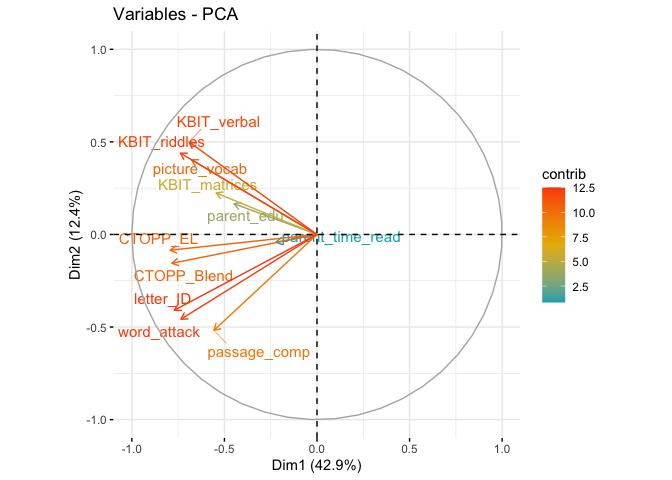

```r
viz_pca <- prcomp(scaled_PKp1, center = TRUE,scale. = TRUE) #run PCA with a component for each variable.

#Graph variables
fviz_pca_var(viz_pca,
             col.var = "contrib", # Color by contributions to the PC
             gradient.cols = c("#00AFBB", "#E7B800", "#FC4E07"), #choose gradient colors
             repel = TRUE #Avoid overlapping text
             )
```

According to the Graph there appears to be at least two components, maybe three. One component seems to represent relational knowledge (KBIT, picture vocab), another looks reading related (CTOPP and WJ scores), and there may be a third component representing parent involvement (parent time read, parent education).

### STEP 4: Bartlett’s test

Next, I will run Bartletts test of sphericity to asses whether the r-matrix is an identity matrix. If the p value is above .05 (not significant), variables are not related to one another and a PCA should not be run. If the p value is below .05, I can proceed and conduct a PCA.

```r
cortest.bartlett(scaled_PKp1, 458) #run Bartletts test of sphericity. 458 equals sample size
```

```
## R was not square, finding R from data
```

```
## $chisq
## [1] 2063.324
##
## $p.value
## [1] 0
##
## $df
## [1] 55
```

```r
#p value below .05, so it is not an identity matrix
```

### STEP 5: KMO

For step 5, I need to assess sampling adequacy for each variable in the model using the Kaiser-Meyer-Olkin (KMO) index. The KMO measures the proportion of variance among variables that might be common variance. MSA values .7 or higher indicate data suitable for use in a factor analysis.

```r
KMO(scaled_PKp1) #run KMO, looking for good values between above .7
```

```
## Kaiser-Meyer-Olkin factor adequacy
## Call: KMO(r = scaled_PKp1)
## Overall MSA =  0.87
## MSA for each item =
## parent_time_read       parent_edu      CTOPP_Blend         CTOPP_EL
##             0.82             0.88             0.90             0.91
##        letter_ID    picture_vocab     passage_comp      word_attack
##             0.83             0.88             0.91             0.83
##    KBIT_matrices     KBIT_riddles      KBIT_verbal
##             0.93             0.86             0.85
```

### STEP 6: Baseline PCA

For step 6, I will select the number of components in my analysis and run a baseline PCA. After assessing the ss loadings and cumulative variance I will use the eigenvalue to create a scree plot to look for a point of inflection.

```r
pca_base <- principal(scaled_PKp1, nfactors = 11, rotate = "none") #run pca with 12 factors for 12 variables

pca_base #results
```

```
## Principal Components Analysis
## Call: principal(r = scaled_PKp1, nfactors = 11, rotate = "none")
## Standardized loadings (pattern matrix) based upon correlation matrix
##                   PC1   PC2   PC3   PC4   PC5   PC6   PC7   PC8   PC9  PC10
## parent_time_read 0.22 -0.04  0.87  0.40  0.09 -0.11  0.08 -0.04  0.03  0.01
## parent_edu       0.45  0.17  0.40 -0.73  0.24  0.08 -0.08  0.08 -0.03 -0.03
## CTOPP_Blend      0.78 -0.16 -0.05 -0.12 -0.12 -0.31  0.28 -0.02 -0.31  0.23
## CTOPP_EL         0.79 -0.08 -0.10 -0.07 -0.15 -0.17  0.35  0.20  0.31 -0.19
## letter_ID        0.77 -0.41  0.01  0.02  0.00 -0.05 -0.34  0.01  0.03 -0.13
## picture_vocab    0.68  0.40  0.03  0.15 -0.32  0.06 -0.28  0.36  0.00  0.18
## passage_comp     0.56 -0.52 -0.03  0.11  0.13  0.58  0.18  0.11 -0.06  0.08
## word_attack      0.74 -0.46 -0.08 -0.01 -0.07 -0.13 -0.25 -0.26  0.06  0.02
## KBIT_matrices    0.54  0.22 -0.28  0.22  0.69 -0.17 -0.04  0.09  0.04  0.07
## KBIT_riddles     0.74  0.44 -0.06  0.17 -0.06  0.13  0.03 -0.11 -0.27 -0.35
## KBIT_verbal      0.69  0.50 -0.03 -0.03 -0.07  0.20  0.08 -0.36  0.21  0.18
##                   PC11 h2       u2 com
## parent_time_read  0.01  1  3.3e-16 1.7
## parent_edu        0.05  1 -1.3e-15 2.9
## CTOPP_Blend      -0.07  1  2.2e-16 2.5
## CTOPP_EL          0.03  1  5.6e-16 2.4
## letter_ID        -0.32  1 -6.7e-16 2.5
## picture_vocab     0.07  1 -4.4e-16 3.7
## passage_comp      0.03  1  1.2e-15 3.5
## word_attack       0.29  1  1.0e-15 2.8
## KBIT_matrices     0.03  1  6.7e-16 3.0
## KBIT_riddles      0.05  1  0.0e+00 2.8
## KBIT_verbal      -0.12  1  8.9e-16 3.2
##
##                        PC1  PC2  PC3  PC4  PC5  PC6  PC7  PC8  PC9 PC10 PC11
## SS loadings           4.71 1.36 1.02 0.82 0.72 0.59 0.51 0.41 0.32 0.31 0.22
## Proportion Var        0.43 0.12 0.09 0.07 0.07 0.05 0.05 0.04 0.03 0.03 0.02
## Cumulative Var        0.43 0.55 0.65 0.72 0.79 0.84 0.89 0.92 0.95 0.98 1.00
## Proportion Explained  0.43 0.12 0.09 0.07 0.07 0.05 0.05 0.04 0.03 0.03 0.02
## Cumulative Proportion 0.43 0.55 0.65 0.72 0.79 0.84 0.89 0.92 0.95 0.98 1.00
##
## Mean item complexity =  2.8
## Test of the hypothesis that 11 components are sufficient.
##
## The root mean square of the residuals (RMSR) is  0
##  with the empirical chi square  0  with prob <  NA
##
## Fit based upon off diagonal values = 1
```

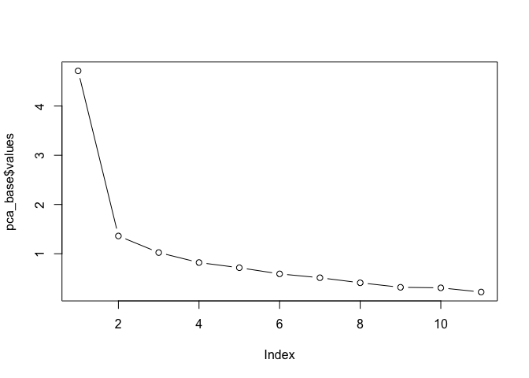

```r
plot(pca_base$values, type = "b") #scree plot using eigen values, plots the eigenvalues (y) against the factor number (x)
```

```r
#indicates 3 variables
```

The first three principal components (PC1-PC3) have SS loadings above 1 and a cumulative variance of .65, indicating those 3 components explain a large amount of variance (65%). These results suggest I should include 3 components in my final analysis. This decision is further solidified by the scree plot, as the curve starts to flatten at 3 components.

### STEP 7: Check that residuals are normally distributed

For step 7 I will run a PCA with 3 factors, make a correlation matrix, and use the matrix and pca loadings to get the factor residuals. Then, I will make a histogram to check if those residuals are normally distributed.

```r
pca_resid <- principal(scaled_PKp1, nfactors = 3, rotate = "none") #run pca with 3 factors
pca_resid
```

```
## Principal Components Analysis
## Call: principal(r = scaled_PKp1, nfactors = 3, rotate = "none")
## Standardized loadings (pattern matrix) based upon correlation matrix
##                   PC1   PC2   PC3   h2   u2 com
## parent_time_read 0.22 -0.04  0.87 0.81 0.19 1.1
## parent_edu       0.45  0.17  0.40 0.39 0.61 2.3
## CTOPP_Blend      0.78 -0.16 -0.05 0.64 0.36 1.1
## CTOPP_EL         0.79 -0.08 -0.10 0.65 0.35 1.1
## letter_ID        0.77 -0.41  0.01 0.76 0.24 1.5
## picture_vocab    0.68  0.40  0.03 0.62 0.38 1.6
## passage_comp     0.56 -0.52 -0.03 0.58 0.42 2.0
## word_attack      0.74 -0.46 -0.08 0.76 0.24 1.7
## KBIT_matrices    0.54  0.22 -0.28 0.43 0.57 1.9
## KBIT_riddles     0.74  0.44 -0.06 0.74 0.26 1.6
## KBIT_verbal      0.69  0.50 -0.03 0.73 0.27 1.8
##
##                        PC1  PC2  PC3
## SS loadings           4.71 1.36 1.02
## Proportion Var        0.43 0.12 0.09
## Cumulative Var        0.43 0.55 0.65
## Proportion Explained  0.66 0.19 0.14
## Cumulative Proportion 0.66 0.86 1.00
##
## Mean item complexity =  1.6
## Test of the hypothesis that 3 components are sufficient.
##
## The root mean square of the residuals (RMSR) is  0.08
##  with the empirical chi square  295.21  with prob <  5.5e-48
##
## Fit based upon off diagonal values = 0.96
```

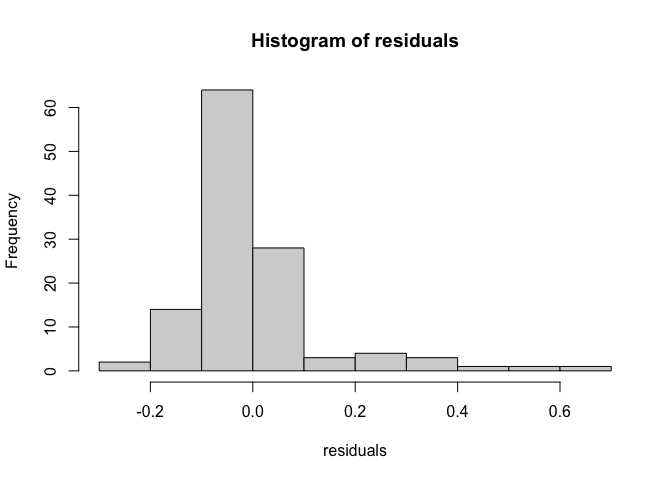

```r
corMatrix<-cor(scaled_PKp1) #correlation matrix for final data

residuals<-factor.residuals(corMatrix, pca_resid$loadings) #create object from the correlation matrix and the pca loading containing the factor residuals

hist(residuals) #checking if residuals are normally distributed
```

### STEP 8: Informed PCA with specific number of components

For step 8 I will run an informed PCA with 3 components based off of the results of my baseline pca. I will also rotate the data using a promax rotation because factors are correlated to each other. Rotating the data will rotate the factor axes resulting in variables loading mostly on one factor. Results of this analysis will be discussed after collecting factor scores.

```r
pca_final <- principal(scaled_PKp1, nfactors = 3, rotate = "promax") #promax rotation
pca_final #results
```

```
## Principal Components Analysis
## Call: principal(r = scaled_PKp1, nfactors = 3, rotate = "promax")
## Standardized loadings (pattern matrix) based upon correlation matrix
##                    RC2   RC1   RC3   h2   u2 com
## parent_time_read  0.04 -0.06  0.90 0.81 0.19 1.0
## parent_edu        0.02  0.36  0.44 0.39 0.61 1.9
## CTOPP_Blend       0.62  0.27  0.00 0.64 0.36 1.4
## CTOPP_EL          0.55  0.36 -0.04 0.65 0.35 1.7
## letter_ID         0.87 -0.02  0.07 0.76 0.24 1.0
## picture_vocab    -0.04  0.80  0.06 0.62 0.38 1.0
## passage_comp      0.87 -0.24  0.02 0.58 0.42 1.2
## word_attack       0.91 -0.07 -0.02 0.76 0.24 1.0
## KBIT_matrices     0.12  0.58 -0.26 0.43 0.57 1.5
## KBIT_riddles     -0.03  0.88 -0.02 0.74 0.26 1.0
## KBIT_verbal      -0.13  0.92  0.01 0.73 0.27 1.0
##
##                        RC2  RC1  RC3
## SS loadings           3.04 2.97 1.09
## Proportion Var        0.28 0.27 0.10
## Cumulative Var        0.28 0.55 0.65
## Proportion Explained  0.43 0.42 0.15
## Cumulative Proportion 0.43 0.85 1.00
##
##  With component correlations of
##      RC2  RC1  RC3
## RC2 1.00 0.55 0.17
## RC1 0.55 1.00 0.20
## RC3 0.17 0.20 1.00
##
## Mean item complexity =  1.3
## Test of the hypothesis that 3 components are sufficient.
##
## The root mean square of the residuals (RMSR) is  0.08
##  with the empirical chi square  295.21  with prob <  5.5e-48
##
## Fit based upon off diagonal values = 0.96
```

```r
print.psych(pca_final, cut = 0.3, sort = TRUE) #including loadings over .3
```

```
## Principal Components Analysis
## Call: principal(r = scaled_PKp1, nfactors = 3, rotate = "promax")
## Standardized loadings (pattern matrix) based upon correlation matrix
##                  item   RC2   RC1   RC3   h2   u2 com
## word_attack         8  0.91             0.76 0.24 1.0
## letter_ID           5  0.87             0.76 0.24 1.0
## passage_comp        7  0.87             0.58 0.42 1.2
## CTOPP_Blend         3  0.62             0.64 0.36 1.4
## CTOPP_EL            4  0.55  0.36       0.65 0.35 1.7
## KBIT_verbal        11        0.92       0.73 0.27 1.0
## KBIT_riddles       10        0.88       0.74 0.26 1.0
## picture_vocab       6        0.80       0.62 0.38 1.0
## KBIT_matrices       9        0.58       0.43 0.57 1.5
## parent_time_read    1              0.90 0.81 0.19 1.0
## parent_edu          2        0.36  0.44 0.39 0.61 1.9
##
##                        RC2  RC1  RC3
## SS loadings           3.04 2.97 1.09
## Proportion Var        0.28 0.27 0.10
## Cumulative Var        0.28 0.55 0.65
## Proportion Explained  0.43 0.42 0.15
## Cumulative Proportion 0.43 0.85 1.00
##
##  With component correlations of
##      RC2  RC1  RC3
## RC2 1.00 0.55 0.17
## RC1 0.55 1.00 0.20
## RC3 0.17 0.20 1.00
##
## Mean item complexity =  1.3
## Test of the hypothesis that 3 components are sufficient.
##
## The root mean square of the residuals (RMSR) is  0.08
##  with the empirical chi square  295.21  with prob <  5.5e-48
##
## Fit based upon off diagonal values = 0.96
```

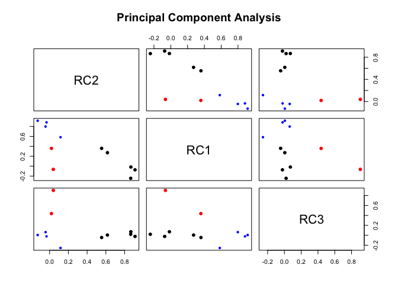

```r
plot(pca_final) #plot final PCA results
```

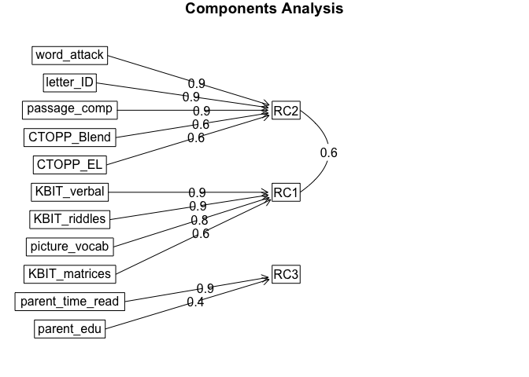

```r
#The far right on each box shows where the component's observations cluster compared to each other cluster
#component 1 is black
#component 2 is blue
#component 3 is red

fa.diagram(pca_final) #diagram components
```

### STEP 9: Collect factor scores

For step 9 I will collect factor scores for each observation, rename columns according to the variables that loaded onto those components, and combine the dataframe with the final PCA scores and the dataframe with the renamed components.

```r
pca_final_scores <- as.data.frame(pca_final$scores) #factor scores for each observation

pca_final_scores <- pca_final_scores %>%
  rename(Relational_Reasoning = RC1, Reading_Comprehension = RC2, Parent_Involvement = RC3) #rename columns

str(PKp1_labeled) #checking structure
```

```
## tibble [458 × 20] (S3: tbl_df/tbl/data.frame)
##  $ PK_ID                      : num [1:458] 10000 10001 10004 10009 10010 ...
##  $ sID                        : num [1:458] 1 1 1 1 1 1 1 1 1 1 ...
##  $ Race                       : chr [1:458] "AA/Black" "AA/Black" "AA/Black" "AA/Black" ...
##  $ Ethnicity                  : chr [1:458] "Not hispanic" "Not hispanic" "Not hispanic" "Not hispanic" ...
##  $ Gender                     : chr [1:458] "female" "male" "female" "female" ...
##  $ free_reduced_lunch         : chr [1:458] "FARL" "FARL" "FARL" "FARL" ...
##  $ limited_english_proficiency: chr [1:458] "Not LEP" "Not LEP" "Not LEP" "Not LEP" ...
##  $ treatment                  : chr [1:458] "treatment" "treatment" "treatment" "treatment" ...
##  $ academic_knowledge         : num [1:458] 14 13 11 8 11 10 11 10 9 12 ...
##  $ parent_time_read           : num [1:458] 3 2 3 2 3 3 2 3 3 3 ...
##  $ parent_edu                 : num [1:458] 4 3 3 2 1 3 2 1 2 4 ...
##  $ CTOPP_Blend                : num [1:458] 6 11 6 8 4 8 4 6 3 6 ...
##  $ CTOPP_EL                   : num [1:458] 8 3 4 3 0 1 0 2 2 3 ...
##  $ letter_ID                  : num [1:458] 12 9 14 15 8 10 12 13 14 16 ...
##  $ picture_vocab              : num [1:458] 20 18 16 12 17 16 17 16 15 15 ...
##  $ passage_comp               : num [1:458] 8 7 0 3 5 6 3 7 4 7 ...
##  $ word_attack                : num [1:458] 3 2 3 2 2 3 3 2 3 3 ...
##  $ KBIT_matrices              : num [1:458] 26 17 17 13 12 11 12 17 14 14 ...
##  $ KBIT_riddles               : num [1:458] 16 12 10 10 12 9 10 13 11 12 ...
##  $ KBIT_verbal                : num [1:458] 22 17 9 8 9 7 5 9 9 14 ...
```

```r
final_data <- cbind(PKp1_labeled, pca_final_scores)#combining dataframes
str(final_data)
```

```
## 'data.frame':    458 obs. of  23 variables:
##  $ PK_ID                      : num  10000 10001 10004 10009 10010 ...
##  $ sID                        : num  1 1 1 1 1 1 1 1 1 1 ...
##  $ Race                       : chr  "AA/Black" "AA/Black" "AA/Black" "AA/Black" ...
##  $ Ethnicity                  : chr  "Not hispanic" "Not hispanic" "Not hispanic" "Not hispanic" ...
##  $ Gender                     : chr  "female" "male" "female" "female" ...
##  $ free_reduced_lunch         : chr  "FARL" "FARL" "FARL" "FARL" ...
##  $ limited_english_proficiency: chr  "Not LEP" "Not LEP" "Not LEP" "Not LEP" ...
##  $ treatment                  : chr  "treatment" "treatment" "treatment" "treatment" ...
##  $ academic_knowledge         : num  14 13 11 8 11 10 11 10 9 12 ...
##  $ parent_time_read           : num  3 2 3 2 3 3 2 3 3 3 ...
##  $ parent_edu                 : num  4 3 3 2 1 3 2 1 2 4 ...
##  $ CTOPP_Blend                : num  6 11 6 8 4 8 4 6 3 6 ...
##  $ CTOPP_EL                   : num  8 3 4 3 0 1 0 2 2 3 ...
##  $ letter_ID                  : num  12 9 14 15 8 10 12 13 14 16 ...
##  $ picture_vocab              : num  20 18 16 12 17 16 17 16 15 15 ...
##  $ passage_comp               : num  8 7 0 3 5 6 3 7 4 7 ...
##  $ word_attack                : num  3 2 3 2 2 3 3 2 3 3 ...
##  $ KBIT_matrices              : num  26 17 17 13 12 11 12 17 14 14 ...
##  $ KBIT_riddles               : num  16 12 10 10 12 9 10 13 11 12 ...
##  $ KBIT_verbal                : num  22 17 9 8 9 7 5 9 9 14 ...
##  $ Reading_Comprehension      : num  0.7176 0.1723 -0.3503 -0.0743 -0.7119 ...
##  $ Relational_Reasoning       : num  2.002 0.563 -0.2 -0.995 -0.794 ...
##  $ Parent_Involvement         : num  0.0989 -0.9346 0.2353 -1.1582 -0.1514 ...
```

## PCA discussion

Results of the PCA indicate there are 2 to 3 components. The first two are strong components, and the third weaker component.

## Model Data using Component Score

Finally, I will run a regression analysis to model the data using the component score rather than the variable score. First, I will create a smaller data frame composed of my PCA components and outcome variable. Next, I will compute a 10-fold cross validation. Computing a 10 fold cross validation allows me to estimate the skill of my ML model and increase its predictive accuracy.

```r
final_data_2 <- final_data %>%
  dplyr::select(academic_knowledge, Relational_Reasoning, Reading_Comprehension, Parent_Involvement) #creating a df for the regression with just the components and outcome variable
```

### 10 fold cross-validation

```r
library(relaimpo)

set.seed(123)#set seed for replication of cross-validation

train.control <- trainControl(method = "cv", number = 10) #method = cross validation, number = ten times (10 fold cross-validation)

#run regression
lm_10 <- train(academic_knowledge ~ Relational_Reasoning + Reading_Comprehension + Parent_Involvement, data = final_data_2,
                           method = "lm",
                           trControl = train.control)

summary(lm_10) #results of regression
```

```
##
## Call:
## lm(formula = .outcome ~ ., data = dat)
##
## Residuals:
##     Min      1Q  Median      3Q     Max
## -4.6493 -0.9284  0.0215  0.8688  3.9795
##
## Coefficients:
##                       Estimate Std. Error t value Pr(>|t|)
## (Intercept)           11.97817    0.06518 183.785   <2e-16 ***
## Relational_Reasoning   1.52464    0.07896  19.309   <2e-16 ***
## Reading_Comprehension  0.10333    0.07859   1.315   0.1892
## Parent_Involvement     0.13581    0.06672   2.036   0.0424 *
## ---
## Signif. codes:  0 '***' 0.001 '**' 0.01 '*' 0.05 '.' 0.1 ' ' 1
##
## Residual standard error: 1.395 on 454 degrees of freedom
## Multiple R-squared:  0.5749, Adjusted R-squared:  0.5721
## F-statistic: 204.7 on 3 and 454 DF,  p-value: < 2.2e-16
```

### Variable Importance

```r
varImp(lm_10)$importance #assess variable importance
```

```
##                          Overall
## Relational_Reasoning  100.000000
## Reading_Comprehension   0.000000
## Parent_Involvement      4.004914
```

### Scatterplot

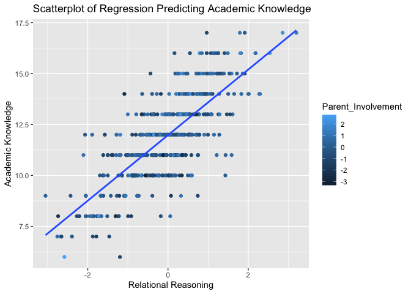

```r
ggplot(final_data_2, aes(y = academic_knowledge, x = Relational_Reasoning, color = Parent_Involvement)) +
  geom_point() +
  stat_smooth(method="lm",se=FALSE) +
  xlab("Relational Reasoning") +
  ylab("Academic Knowledge") +
  ggtitle("Scatterplot of Regression Predicting Academic Knowledge") +
  geom_abline(intercept = 1,
              slope = 1,
              color = "red",
              size = 2)
```